# Linkage Analysis

2020-07-08

### Document History

Original Publish Date: 08 July, 2020

Updated on: 06 May, 2021

In politics few of the players become successful in building a dynasty. Among those successful ones some of them expands their territory to multiple levels. In this post, we look at those families to see what enabled them for their expansion. This analysis exclusively among families.

We use TRUE/FALSE to represent a families linkage.

# ADR

In the first part, we are using ADR data which is available for the years 2012 and 2017 for AE and 2009,2014 and 2019 for GE.

## Summary

This table shows us the number of families with linkage.

Summary table of individuals from families with and without linkages AE: 2012-2017, GE: 2009-2019

| Linkage | Count |
| --- | --- |
| Politically diversified - Yes | 307 |
| Politically diversified - No | 179 |

## Assets

Average assets among families with and without linkages

| Linkage | Total assets | Movable Assets | Immovable Assets |
| --- | --- | --- | --- |
| Politically diversified - Yes | 48472719 | 11610670 | 30778450 |
| Politically diversified - No | 37503980 | 8633294 | 25269354 |

## Crime

This table shows us the proportion of families in each category with one or more serious crimes.

Serious criminal cases among families with and without linkages

| Linkage | Proportion |
| --- | --- |
| Politically diversified - Yes | 0.30 |
| Politically diversified - No | 0.18 |

## Industry

In this section we calculate number of industries they own. According to our survey design Maximum number of industries that a family can have is 3 .

Industry ownership among families with and without linkages

| Politician’s identity | Average number of ownersip |
| --- | --- |
| Politically diversified - Yes | 1.8 |
| Politically diversified - No | 1.5 |

This table shows the break-up of the rent type among those industry owners

| Politician’s identity | rent-type | Proportion |
| --- | --- | --- |
| Politically diversified - Yes | non-rent-thick | 0.35 |
| Politically diversified - Yes | rent-thick | 0.65 |
| Politically diversified - No | non-rent-thick | 0.48 |
| Politically diversified - No | rent-thick | 0.52 |

## Caste

This sections shows the composition of caste with regards linkage.

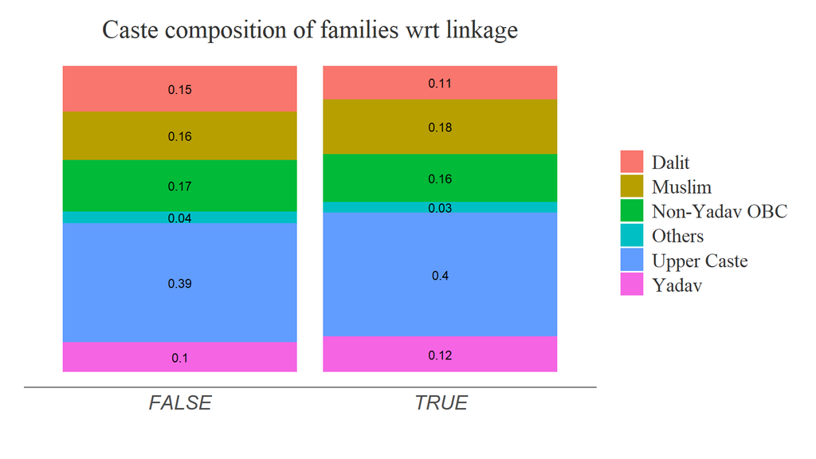

## MPLADS

MPLADS data is available for the year 2004 & 2009. The following table summarises the families with and without linkage.

Summary stat of families in 2004 & 2009 GE wrt linkage

| Linkage | Count |
| --- | --- |
| Politically diversified - Yes | 37 |
| Politically diversified - No | 14 |

MPLADS prjects and spending wrt linkage

| Type of constiuency | Average number of contracts | Avergae expenditure per project |
| --- | --- | --- |
| Politically diversified - Yes | 473 | 318457 |
| Politically diversified - No | 223 | 314624 |

### Project count and expenditure

This section looks at the categorical distribution of type of MPLADS projects and spending among families with regards to their linkage.

The following stacked chart depicts the composition of both number of projects and the expenditure with regards to linkage.

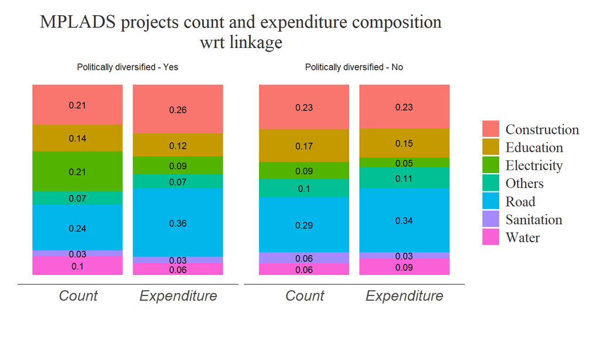

This bar chart depicts the average number of projects in each category withregards to linkage.

[figure not shown]

This bar chart depicts the average cost incurred for each category of projects withregards to family linkage.

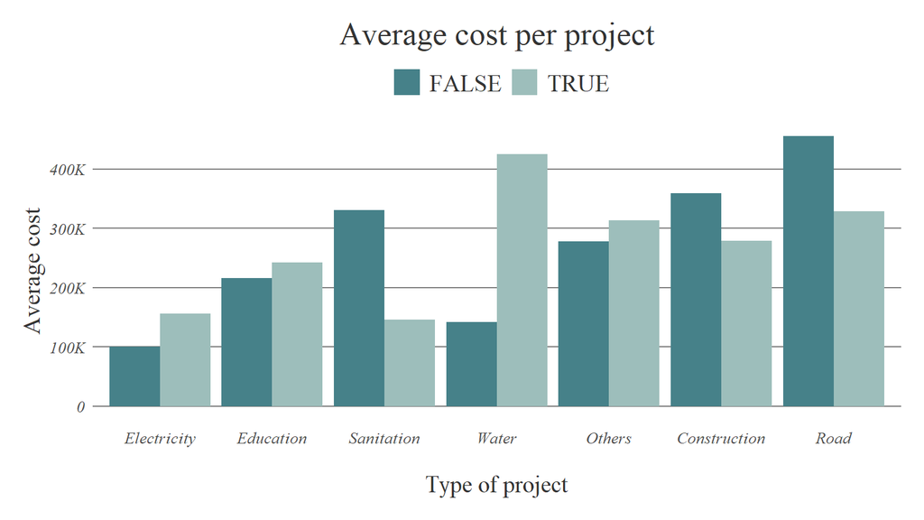

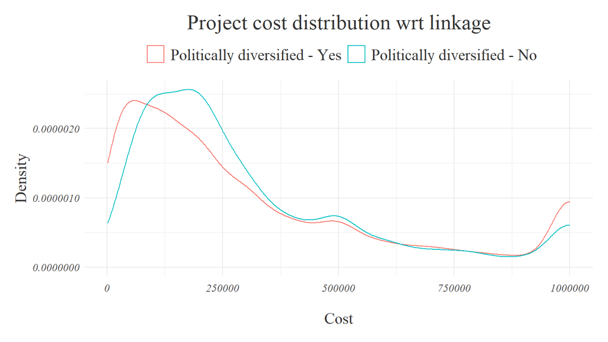

### cost categories

We categorised the project expenditure to three -

Categories:

Here we are analysing how they differes withregards to families linkage status

Project cost categories wrt politician’s identity

| Linkage | Cost Categry | Proportion of projects |
| --- | --- | --- |
| Politically diversified - Yes | Low | 0.50 |
| Politically diversified - No | Low | 0.48 |
| Politically diversified - Yes | Medium | 0.29 |
| Politically diversified - No | Medium | 0.34 |
| Politically diversified - Yes | High | 0.22 |
| Politically diversified - No | High | 0.18 |

## Raphael

Raphael’s booth level data is available for the last 3 UP assembly elections. We use the booth level voting data to see the spread of the vote share.

The following table summarises the families with linkages for last 3 assembly elections in UP.

| Linkage | Count |
| --- | --- |
| Politically diversified - Yes | 182 |
| Politically diversified - No | 104 |

# Vote dispersion

Vote dispersion at booth level wrt Politicians identity

| Politician’s Identity | Variance |
| --- | --- |
| Politically diversified - Yes | 303 |
| Politically diversified - No | 368 |

Vote dispersion at booth level wrt Politicians identity

| Politician’s Identity | SD |
| --- | --- |
| Politically diversified - Yes | 17.1 |
| Politically diversified - No | 18.7 |

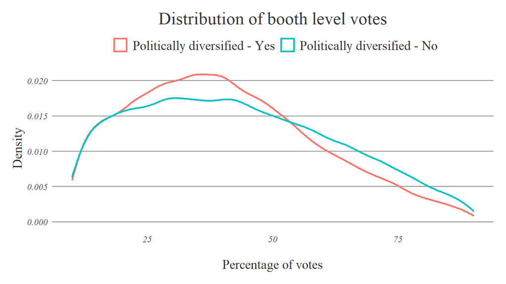